# Git par la pratique

## Plan de la présentation

- Créer un repo sur GitHub
- Créer un projet Rstudi (git clone)
- Copier votre projet
- Faire des changements, enregistrer, et commit
- Envoyer vos changements sur GitHub

## Dites bonjour à git

Pour vérifier l’installation de git et établir la connexion :

```r
## install if needed (do this exactly once):
## install.packages("usethis")

library(usethis)
use_git_config(user.name = "Jane Doe", user.email = "jane@example.org")
```

## Make a repo on GitHub

Go to https://github.com and make sure you are logged in.

## Créer un nouveau repo

[figure not shown]

## Initialiser le nouveau repo

[figure not shown]

## Copier le lien pour cloner le repo

[figure not shown]

## New RStudio Project via git clone

## Créer un nouveau projet

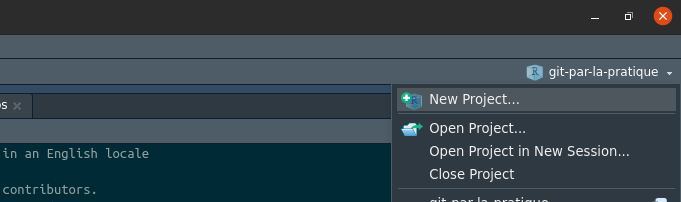

## Créer un nouveau projet

[figure not shown]

## Créer un nouveau projet

[figure not shown]

## Créer un nouveau projet

[figure not shown]

## Votre dossier actuel

- Si votre dossier est gros **attention !!!**
- nettoyage du dossier (rapide)
  - vos documents
  - vos données (si vous en avez)

## Copier les fichiers dans le nouveau dossier

- Ouvrir l’explorateur de fichier par exemple

## Git dans Rstudio

[figure not shown]

## Git dans Rstudio

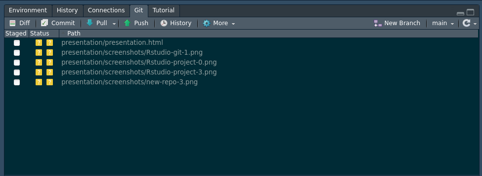

## Stage and commit

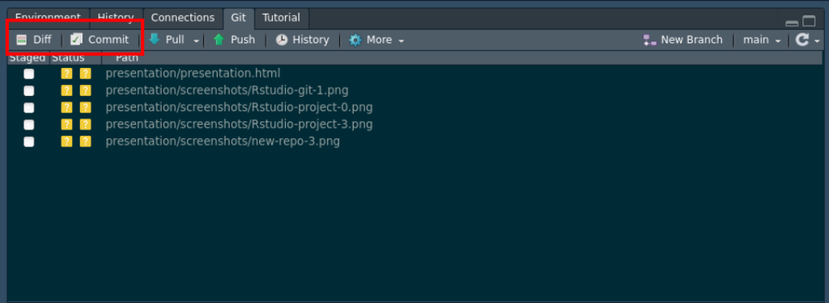

## Stage and commit

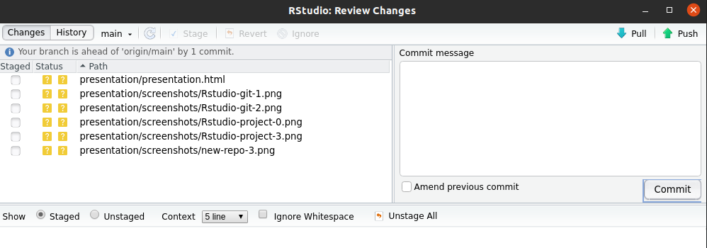

## Stage and commit

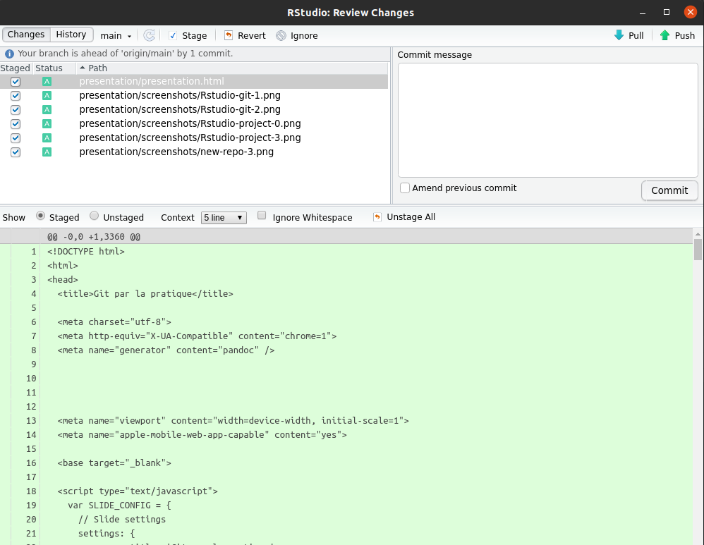

## Stage and commit

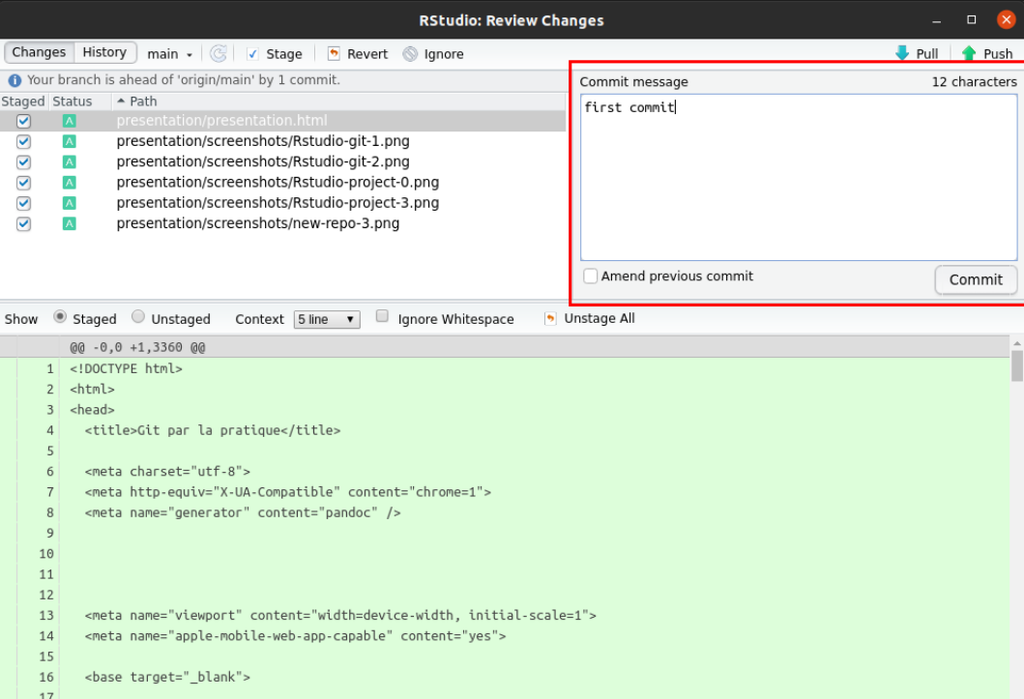

## Push your local changes to GitHub

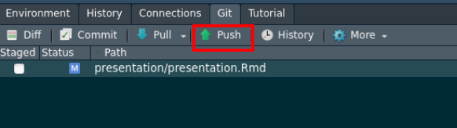

Click the green “Push” button to send your local changes to GitHub.

## Confirm the local change propagated to the GitHub remote

Go back to the browser. I assume we’re still viewing your new GitHub repo. https://github.com

Refresh.

You should see all the project files you committed there.

If you click on “commits,” you should see one with the message your wrote.

## Faire des changements dans votre dossier

- faire des changements (commenter votre code par exemple)
- sauvegarder vos fichiers
- regarder git Diff

## Si vous voulez garder ces changements

- sélectionner les fichiers à changer (stage)
- regarder les changements
- commit

## Pour les changements que vous ne voulez pas garder

[figure not shown]

## Well done

- Désormais, vous savez:
  - initier un dépôt git
  - Le lier avec github
  - Sauvegarder vos changements

. . .

- Comment ignorer les fichiers que l’on ne peut pas suivre

## Utiliser gitignore

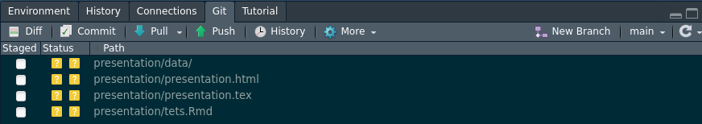

## Utiliser gitignore

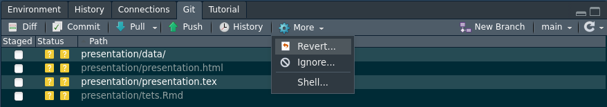

## Utiliser gitignore

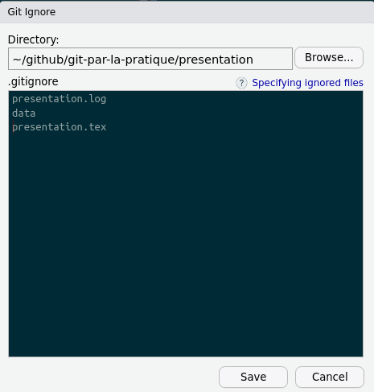

## Utiliser gitignore

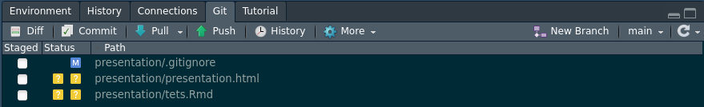

## Utiliser gitignore

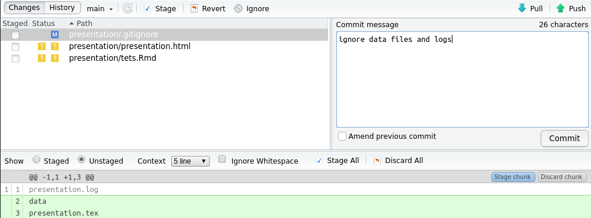

## À vous de jouer

- Rejoingnez une salle
- Réalisez le TP à l’aide de la présentation et du tuto